# Course project 1

zengyujia

2025-03-21

## Introduction

This is the peer-graded assignment for the Reproducible Research Course by Johns Hopkins University at Coursera, which is the 5th out of 10 courses in the [Data Science Specialization](https://www.coursera.org/specializations/jhu-data-science).

The objective of this assignment is to make a reproducible report of an individual’s activity over a two month period, measured in number of steps. The report will be generated using [knitr](https://yihui.name/knitr/).

As provided in Professor Peng’s [original repository](https://github.com/rdpeng/RepData_PeerAssessment1), this repository is self-contained — all data and assignment instructions necessary to reproduce this work are available in the same place.

## Setting up the report

First, we need to setup the report options using, and install —if necessary— and load all the required packages to successfully complete this assignment.

```r
## Loading the necessary package for reproducing the assingment
if (!require(knitr)) {
    install.packages("knitr")
}
library(knitr)

if (!require(tidyverse)) {
    install.packages("tidyverse")
}
library(tidyverse)

## Setting up all code chunks according to the assignment specs
knitr::opts_chunk$set(
    eval = TRUE,
    echo = TRUE,
    tidy = TRUE,
    results = "markup",
    include = TRUE,
    message = FALSE,
    warning = FALSE,
    knitr.table.format = "markdown",
    tidy.opts = list(width.cutoff = 80),
    fig.align = "center",
    fig.path = "figure/",
    highlight = TRUE
)
```

## Loading and preprocessing the data

Instructions: Show any code that is needed to 1. Load the data (i.e. read.csv()) 2. Process/transform the data (if necessary) into a format suitable for your analysis

In the original repository, the data set is compressed in a ZIP file, which we unzip —if necessary— and load the resulting CSV file into the working environment.

No pre-processing was necessary for this data set, as it is already tidy.

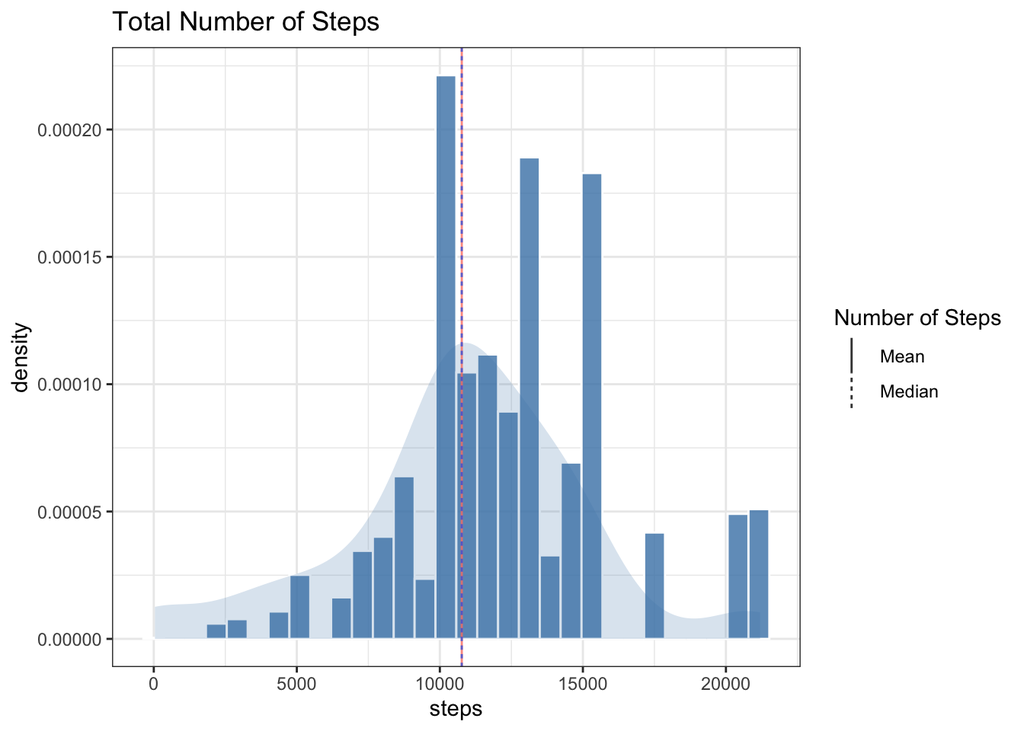

```r
## If necessary, unzipping the data file, and loading it
if (!file.exists("activity.csv") & file.exists("activity.zip")) {
    unzip("activity.zip")
    activity.data <- read_csv(file = "activity.csv")
} else if (file.exists("activity.csv")) {
    activity.data <- read_csv(file = "activity.csv")
} else {
    message("Activity Monitoring Data (default) from Rep Research course was not found")
}
data <- read.csv("activity.csv")
sum_steps <- data %>%
    group_by(date) %>%
    summarise(steps = sum(steps))

mean_median_steps <- sum_steps %>%
    summarise(Mean = mean(steps, na.rm = TRUE), Median = median(steps, na.rm = TRUE)) %>%
    gather()
ggplot(data = sum_steps, mapping = aes(x = steps, y = ..density..)) + geom_histogram(aes(weight = steps),
    fill = "steelblue", colour = "white", alpha = 0.8) + geom_density(fill = "steelblue",
    colour = NA, alpha = 0.2) + ggtitle(list(title = "Total Number of Steps", subtitle = "Distribution of Total Number of Steps Taken Each Day",
    x = "Steps", y = "Density")) + geom_vline(data = mean_median_steps, aes(xintercept = value,
    linetype = key), size = 0.5, alpha = 0.8, colour = c("salmon", "royalblue")) +
    scale_linetype_discrete(name = "Number of Steps") + theme_bw()
```

## Mean and Median

```r
sum_steps %>%
    summarise(`Mean number of steps taken per day` = round(mean(steps, na.rm = TRUE)),
        `Median number of steps taken per day` = round(median(steps, na.rm = TRUE))) %>%
    kable(align = "c")
```

| Mean number of steps taken per day | Median number of steps taken per day |
| --- | --- |
| 10766 | 10765 |

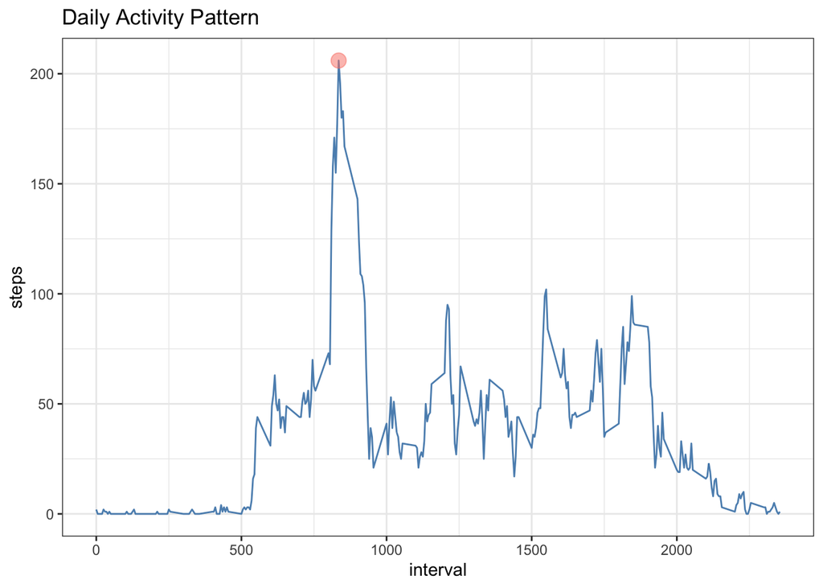

```r
avg_steps_day <- data %>%
    group_by(interval) %>%
    summarise(steps = round(mean(steps, na.rm = TRUE))) %>%
    filter(!is.nan(steps))
max.steps <- avg_steps_day[which.max(avg_steps_day$steps), ]
ggplot(data = avg_steps_day, mapping = aes(x = interval, y = steps)) + geom_line(size = 0.5,
    colour = "steelblue", alpha = 0.9) + ggtitle(list(title = "Daily Activity Pattern",
    subtitle = "Average number of steps taken by 5-min interval, across all days",
    y = "Number of Steps", x = "Interval")) + geom_point(data = max.steps, mapping = aes(x = interval,
    y = steps), size = 4, alpha = 0.5, colour = "salmon") + theme_bw()
```

## NA counts

```r
nas.df <- data %>%
    sapply(is.na) %>%
    as_tibble() %>%
    summarise(Steps = sum(steps), Date = sum(date), Interal = sum(interval))
row.names(nas.df) <- c("Numbers of NAs")
nas.df %>%
    kable(caption = "Number of Missing Values of each Variable", align = "c")
```

Number of Missing Values of each Variable

| Steps | Date | Interal |
| --- | --- | --- |
| 2304 | 0 | 0 |

## NA imputation

```r
non.NA <- data %>%
    group_by(interval) %>%
    summarise(steps = round(mean(steps, na.rm = TRUE, trim = 0.05)))
imp.activity.data <- full_join(x = data, y = non.NA, by = "interval") %>%
    mutate(steps = ifelse(test = is.na(steps.x), yes = steps.y, no = steps.x)) %>%
    select(steps, date, interval)
```

## Hist of compelete data

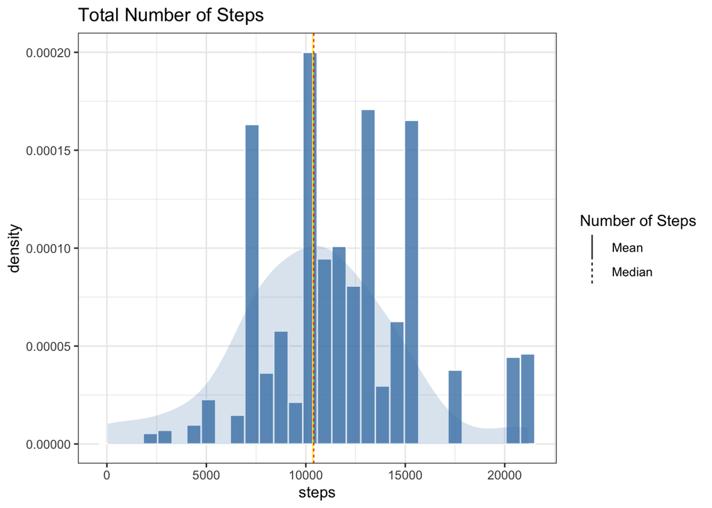

```r
steps.day.df <- imp.activity.data %>%
    group_by(date) %>%
    summarise(steps = sum(steps))
mean.median.steps <- steps.day.df %>%
    summarise(Mean = round(mean(steps, na.rm = TRUE)), Median = round(median(steps,
        na.rm = TRUE))) %>%
    gather()

ggplot(data = steps.day.df, mapping = aes(x = steps, y = ..density..)) + geom_histogram(aes(weight = steps),
    fill = "steelblue", colour = "white", alpha = 0.8) + geom_density(fill = "steelblue",
    colour = NA, alpha = 0.2) + ggtitle(list(title = "Total Number of Steps", subtitle = "Distribution of Total Number of Steps Taken Each Day",
    x = "Steps", y = "Density")) + geom_vline(data = mean.median.steps, aes(xintercept = value,
    linetype = key), size = 0.5, alpha = 0.8, colour = c("yellow", "red")) + scale_linetype_discrete(name = "Number of Steps") +
    theme_bw()
```